# CIA III: Dynamic Price Elasticity Framework

Analysis of iPhone 15 vs iPhone 16 Pro Sales Divergence

MBA Business Analytics

2026-05-03

# Project Overview

This analysis investigates cross-price elasticity and cannibalisation effects between the iPhone 15 and iPhone 16 Pro. The project provides a data-driven framework for understanding how promotional pricing of a base-model smartphone affects the sales performance of a premium-tier flagship within the same product ecosystem.

By implementing an Interrupted Time-Series design in R, this study assesses whether spikes in sales of discounted models represent “new growth” or merely “stolen demand” from high-margin premium models. The final output serves as a Decision Support System (DSS) for retail managers to optimise price floors and protect overall category margins.

# Problem Statement

Domain: Marketing & Retail Analytics

Context: In the consumer electronics sector, promotional events are used to clear inventory. However, when a base model (iPhone 15) is discounted, it often competes directly with the premium flagship (iPhone 16 Pro).

Specific Issue: “Cannibalisation” occurs when these discounts do not attract new market segments but instead encourage existing premium-tier customers to “downgrade” to the cheaper model. This results in Margin Erosion, where the increase in volume for the base model is offset by a loss of high-margin sales in the premium category.

### Need for a Structured Solution

Retail managers lack a quantitative method to distinguish between “Growth Sales” and “Cannibalised Sales.” A structured R-framework is necessary to:

- **Quantify substitution effects** using Cross-Price Elasticity.
- **Identify divergence patterns** through time-series visualisation.
- **Automate risk classification** to inform future pricing strategies and protect overall category profitability.

# Variables Identified

To facilitate a robust analytical framework, the following variables were extracted and utilised from the primary dataset:

- **Date**: The chronological timeline used for tracking sales trends and isolating specific promotional windows (Temporal).
- **Final_Price**: The independent variable ($X$) representing the actual market price in INR after discounts.
- **Quantity_Sold**: The dependent variable ($Y$) represents the daily volume of units sold across various retail points.

# Framework

The project implements an Interrupted Time-Series design. By defining “Baseline” periods (full price) and “Sale” periods (discounted price) across a 6-month dataset, the system calculates the percentage changes in price and quantity.

The framework utilises the following logical flow:

- **Data Ingestion:** Reading multi-dimensional sales data from Excel.
- **Feature Engineering:** Calculating mean prices and quantities for specific temporal windows.
- **Cross-Price Elasticity Calculation:** Applying the mathematical formula.
- **Decision Logic:** If the resulting elasticity score is positive and high (XED > 0.5), the framework confirms cannibalisation and suggests a strategic adjustment to the price floor.

# Data Structures Used & Justification

### Data Frame (`sales_data`)

- **Justification**: The primary dataset contains heterogeneous data types, including Dates, Characters, and Numerics. A Data Frame is the most efficient structure in R for handling tabular time-series data, allowing for seamless filtering, subsetting, and vectorised operations during the analysis.

### Named List (`results`)

- **Justification**: Lists in R are designed to store non-uniform data. We utilise a Named List to group the numeric **Elasticity Score** with the character-based **Risk Status** for each event. This provides a structured, dictionary-like object that is easy to access for reporting.

# Data Flow Diagram

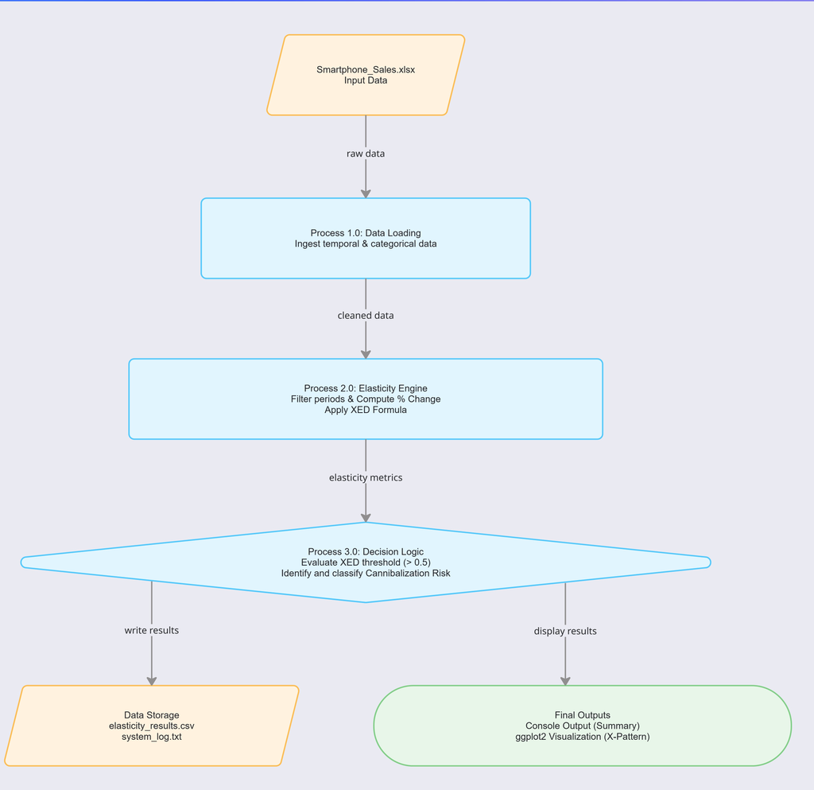

# Setup & File Paths

```r
library(dplyr)
```

```r
library(ggplot2)
library(readxl)

input_path <- "C:/Users/alexa/Downloads/smartphone_sales.xlsx"
output_csv <- "C:/Users/alexa/Downloads/elasticity_results.csv"
log_file   <- "C:/Users/alexa/Downloads/system_log.txt"
array_file <- "C:/Users/alexa/Downloads/promotional_array_data.rds"
```

# Data Loading Code snippet

```r
# load_data(): Ingests the Excel sales file and coerces the Date column to
# R's Date class for accurate time-window filtering downstream.
load_data <- function(path){
  tryCatch({
    data <- read_excel(path)          # Read all sheets from the Excel file
    data$Date <- as.Date(data$Date)   # Coerce to Date for temporal subsetting
    return(data)
  }, error = function(e){
    # Catches missing file, permission errors, or malformed Excel structure
    message("CRITICAL ERROR: File not found.")
    return(NULL)
  })
}
```

# Helper Function: Metric Extraction

```r
# extract_metrics(): Reusable helper that filters data to a given date window
# and returns mean Price and Quantity for both iPhone models.
# Used by analyze_risk() AND the array-building loop to eliminate code duplication.
extract_metrics <- function(data, start_date, end_date){

  # Step 1: Subset rows that fall within the specified date window
  window <- subset(data, Date >= as.Date(start_date) & Date <= as.Date(end_date))

  # Step 2: Calculate mean Price and Quantity for each model within this window
  list(
    p15 = mean(subset(window, Model == "iPhone 15")$Final_Price,      na.rm = TRUE),
    q15 = mean(subset(window, Model == "iPhone 15")$Quantity_Sold,    na.rm = TRUE),
    p16 = mean(subset(window, Model == "iPhone 16 Pro")$Final_Price,  na.rm = TRUE),
    q16 = mean(subset(window, Model == "iPhone 16 Pro")$Quantity_Sold, na.rm = TRUE)
  )
}
```

# S3 Class Code snippet

```r
# new_PromotionEvent(): Constructor for the S3 class 'PromotionEvent'.
# Encapsulates the four date boundaries that define one promotional cycle:
# a pre-promotion baseline window and an active sale window.
new_PromotionEvent <- function(name, b1, b2, s1, s2){
  structure(
    list(
      name       = name,           # Human-readable label (e.g. "Valentine")
      base_start = as.Date(b1),    # Start of the full-price baseline period
      base_end   = as.Date(b2),    # End of the full-price baseline period
      sale_start = as.Date(s1),    # Start of the discounted sale period
      sale_end   = as.Date(s2)     # End of the discounted sale period
    ),
    class = "PromotionEvent"       # Assigns S3 class for method dispatch
  )
}
```

# Method Code snippet

```r
# Generic S3 dispatch function — routes analyze_risk() to the correct method
# based on the class of the 'obj' argument.
analyze_risk <- function(obj, data){
  UseMethod("analyze_risk")
}

# analyze_risk.PromotionEvent(): Core analytical method.
# Computes cross-price elasticity (XED) between iPhone 15 (price trigger)
# and iPhone 16 Pro (quantity response) for one promotional event.
analyze_risk.PromotionEvent <- function(obj, data){

  tryCatch({

    # Guard clause: abort immediately if the dataset is missing or empty
    if(is.null(data) || nrow(data) == 0){
      stop("Dataset is empty.")
    }

    # Step 1: Extract mean price and quantity for both models in each window
    # Uses the reusable extract_metrics() helper — no duplicated subsetting logic
    base_m <- extract_metrics(data, obj$base_start, obj$base_end)
    sale_m <- extract_metrics(data, obj$sale_start, obj$sale_end)

    # Step 2: Compute Cross-Price Elasticity of Demand (XED)
    # Formula: (% change in Qty of iPhone 16 Pro) / (% change in Price of iPhone 15)
    elasticity <- ((sale_m$q16 - base_m$q16) / base_m$q16) /
                  ((sale_m$p15 - base_m$p15) / base_m$p15)

    # Step 3: Classify cannibalisation risk based on the elasticity threshold
    status <- ifelse(elasticity > 0.5, "High Cannibalization",
                     ifelse(elasticity > 0, "Moderate Cannibalization",
                            "No Cannibalization"))

    # Step 4: Append a timestamped audit entry to the system log file
    write(paste(Sys.time(), "| Event:", obj$name,
                "| Elasticity:", round(elasticity, 3),
                "| Status:", status),
          file = log_file, append = TRUE)

    # Return a named list for downstream report assembly
    return(list(Event = obj$name, Elasticity = elasticity, Status = status))

  }, error = function(e){
    # On any runtime error: log the failure and return a safe NA record
    write(paste(Sys.time(), "| ERROR in", obj$name, "|", e$message),
          file = log_file, append = TRUE)
    return(list(Event = obj$name, Elasticity = NA, Status = "Error"))
  })
}
```